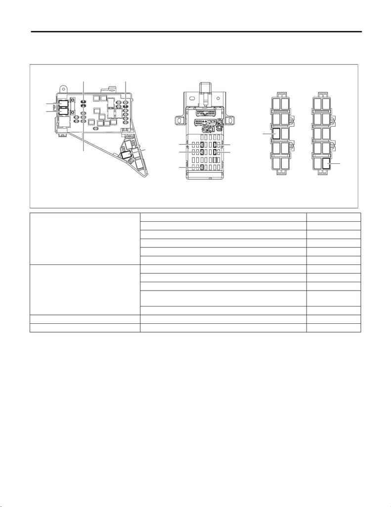

LI-4

Relay and Fuse

LIGHTING SYSTEM

2. Relay and Fuse

A: LOCATION

NOTE:

For other related fuses, refer to the wiring diagram. <Ref. to WI-28, Power Supply Circuit.>

Main fuse box

Headlight relay (HI) (A)

Headlight relay (LO) (B)

Fuse 7.5A (daytime running light relay) (C)

Fuse 30 A (combination light LH/RH) (D)

Fuse 15A (tail and illumination relay, daytime running light relay) (E)

Daytime running light relay (F)

Relay & fuse box

Fuse 7.5A (stop light and brake switch) (G)

Fuse 7.5A (turn signal & hazard unit) (H)

Fuse 10A (trunk room light) (I)

Fuse 15A (front fog light relay) (K)

Relay holder LH Tail & illumination relay (L)

Relay holder RH Front fog light relay (M)

LI-01757

M/B F/B R/H LH R/H RH

(A)

(D) (E)

(B)

(C)

(F)

(L)

(M)

(G)

(H)

(I)

(J)

(K)

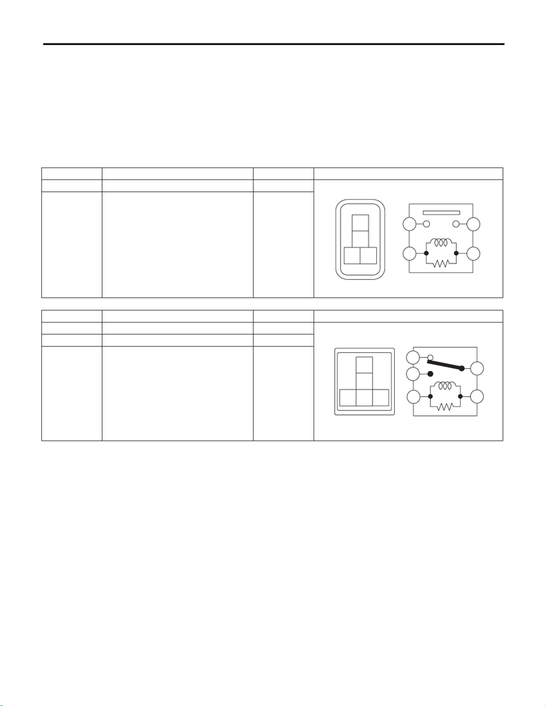

LI-5

Relay and Fuse

LIGHTING SYSTEM

B: INSPECTION

1. CHECK FUSE

1) Remove the fuse and inspect visually.

2) If the fuse is blown out, replace the fuse.

NOTE:

If the fuse is blown again, check the system wiring harness.

2. CHECK RELAY

1) Measure the resistance between relay terminals.

2) Replace the relay if the inspection result is not within the standard value.

Terminal No. Inspection conditions Standard Circuit

1 — 2 Always 1 MΩ or more

1 — 2

Apply battery voltage between terminals

4 and 3.

Less than 1 Ω

Terminal No. Inspection conditions Standard Circuit

1 — 2 Always 1 MΩ or more

1 — 4 Always Less than 1 Ω

1 — 2

Apply battery voltage between terminals

3 and 5.

Less than 1 Ω

LI-01273

1

2

34

2

3 4

1

LI-01274

2

4

3

5

1

1

2

34

5